# Biostat 203B Homework 2

Due Feb 6 @ 11:59PM

Tomoki Okuno

```r
knitr::opts_chunk$set(echo = TRUE, cache = TRUE, cache.lazy = FALSE)
library(tidyverse)
library(data.table)
library(lubridate)
```

```r
os <- sessionInfo()$running
if (str_detect(os, "Linux")) {
  mimic_path <- "/mnt/mimiciv/1.0"
} else if (str_detect(os, "macOS")) {
  mimic_path <- "/Users/tomokiokuno/mimic-iv-1.0"
}
```

In this exercise, we use tidyverse (ggpot2, dplyr, etc) to explore the [MIMIC-IV](https://mimic.mit.edu/docs/iv/) data introduced in [homework 1](https://ucla-biostat-203b.github.io/2022winter/hw/hw1/hw1.html) and to build a cohort of ICU stays.

```r
# tree -s -L 2 /Users/huazhou/Documents/Box\ Sync/MIMIC/mimic-iv-1.0
system(str_c("tree -s -L 2 ", shQuote(mimic_path)), intern = TRUE)
```

```
##  [1] "/mnt/mimiciv/1.0"
##  [2] "├── [       2356]  biostat-203b-2022winter-3fdc2392ac39.json"
##  [3] "├── [        439]  client_secret_34349235653-sidv2drmetcimi1fba4tj024aqth8qmr.apps.googleusercontent.com.json"
##  [4] "├── [       4096]  core"
##  [5] "│   ├── [   17208966]  admissions.csv.gz"
##  [6] "│   ├── [        606]  index.html"
##  [7] "│   ├── [    2955582]  patients.csv.gz"
##  [8] "│   └── [   53014503]  transfers.csv.gz"
##  [9] "├── [       4096]  hosp"
## [10] "│   ├── [     430049]  d_hcpcs.csv.gz"
## [11] "│   ├── [   29531152]  diagnoses_icd.csv.gz"
## [12] "│   ├── [     863239]  d_icd_diagnoses.csv.gz"
## [13] "│   ├── [     579998]  d_icd_procedures.csv.gz"
## [14] "│   ├── [      14898]  d_labitems.csv.gz"
## [15] "│   ├── [   11684062]  drgcodes.csv.gz"
```

[output cut: 28 more lines]

## Q1. `read.csv` (base R) vs `read_csv` (tidyverse) vs `fread` (data.table)

There are quite a few utilities in R for reading plain text data files. Let us test the speed of reading a moderate sized compressed csv file, `admissions.csv.gz`, by three programs: `read.csv` in base R, `read_csv` in tidyverse, and `fread` in the popular data.table package.

Which function is fastest? Is there difference in the (default) parsed data types? (Hint: R function `system.time` measures run times.)

For later questions, we stick to the tidyverse.

**Solution:** I used `system.time` to measure run times for the three functions. Looking at user time, CPU time charged for the execution of user instructions, `fread` was the fastest function.

```r
system.time(tmp_r <- read.csv(str_c(mimic_path,"/core/admissions.csv.gz")))
```

```
##    user  system elapsed
##  39.562   0.210  39.781
```

```r
system.time(tmp_t <- read_csv(str_c(mimic_path,"/core/admissions.csv.gz")))
```

```
##    user  system elapsed
##   3.289   0.159   2.457
```

```r
system.time(tmp_f <- fread(str_c(mimic_path,"/core/admissions.csv.gz")))
```

```
##    user  system elapsed
##   1.206   0.107   1.041
```

```r
str(tmp_r)
```

```
## 'data.frame':    523740 obs. of  15 variables:
##  $ subject_id          : int  14679932 15585972 11989120 17817079 15078341 19124609 17301855 17991012 16865435 13693648 ...
##  $ hadm_id             : int  21038362 24941086 21965160 24709883 23272159 20517215 29732723 24298836 23216961 21640725 ...
##  $ admittime           : Factor w/ 514435 levels "2105-10-04 17:26:00",..: 162283 62357 210124 330971 56261 351331 166789 430755 456181 3345 ...
##  $ dischtime           : Factor w/ 507789 levels "2105-10-12 11:11:00",..: 160158 61694 207314 326516 55632 346651 164592 424886 449948 3316 ...
##  $ deathtime           : Factor w/ 9337 levels "","2110-01-25 09:40:00",..: 1 1 1 1 1 1 1 1 1 1 ...
##  $ admission_type      : Factor w/ 9 levels "AMBULATORY OBSERVATION",..: 4 4 4 4 4 4 4 4 4 4 ...
##  $ admission_location  : Factor w/ 12 levels "","AMBULATORY SURGERY TRANSFER",..: 1 1 1 1 1 1 1 1 1 1 ...
##  $ discharge_location  : Factor w/ 14 levels "","ACUTE HOSPITAL",..: 8 8 8 8 8 8 8 8 8 8 ...
##  $ insurance           : Factor w/ 3 levels "Medicaid","Medicare",..: 3 3 3 3 3 3 3 3 3 3 ...
##  $ language            : Factor w/ 2 levels "?","ENGLISH": 2 2 2 2 2 2 2 2 2 2 ...
##  $ marital_status      : Factor w/ 5 levels "","DIVORCED",..: 4 1 1 1 1 1 1 1 1 1 ...
##  $ ethnicity           : Factor w/ 8 levels "AMERICAN INDIAN/ALASKA NATIVE",..: 7 8 7 5 3 7 8 8 8 8 ...
##  $ edregtime           : Factor w/ 310256 levels "","2109-08-31 02:46:00",..: 1 1 1 1 1 1 1 1 1 1 ...
##  $ edouttime           : Factor w/ 310322 levels "","2109-08-31 07:51:00",..: 1 1 1 1 1 1 1 1 1 1 ...
##  $ hospital_expire_flag: int  0 0 0 0 0 0 0 0 0 0 ...
```

```r
str(tmp_t)
```

```
## spec_tbl_df [523,740 × 15] (S3: spec_tbl_df/tbl_df/tbl/data.frame)
##  $ subject_id          : num [1:523740] 14679932 15585972 11989120 17817079 15078341 ...
##  $ hadm_id             : num [1:523740] 21038362 24941086 21965160 24709883 23272159 ...
##  $ admittime           : POSIXct[1:523740], format: "2139-09-26 14:16:00" "2123-10-07 23:56:00" ...
##  $ dischtime           : POSIXct[1:523740], format: "2139-09-28 11:30:00" "2123-10-12 11:22:00" ...
##  $ deathtime           : POSIXct[1:523740], format: NA NA ...
##  $ admission_type      : chr [1:523740] "ELECTIVE" "ELECTIVE" "ELECTIVE" "ELECTIVE" ...
##  $ admission_location  : chr [1:523740] NA NA NA NA ...
##  $ discharge_location  : chr [1:523740] "HOME" "HOME" "HOME" "HOME" ...
##  $ insurance           : chr [1:523740] "Other" "Other" "Other" "Other" ...
##  $ language            : chr [1:523740] "ENGLISH" "ENGLISH" "ENGLISH" "ENGLISH" ...
##  $ marital_status      : chr [1:523740] "SINGLE" NA NA NA ...
##  $ ethnicity           : chr [1:523740] "UNKNOWN" "WHITE" "UNKNOWN" "OTHER" ...
##  $ edregtime           : POSIXct[1:523740], format: NA NA ...
##  $ edouttime           : POSIXct[1:523740], format: NA NA ...
##  $ hospital_expire_flag: num [1:523740] 0 0 0 0 0 0 0 0 0 0 ...
##  - attr(*, "spec")=
##   .. cols(
##   ..   subject_id = col_double(),
##   ..   hadm_id = col_double(),
##   ..   admittime = col_datetime(format = ""),
##   ..   dischtime = col_datetime(format = ""),
##   ..   deathtime = col_datetime(format = ""),
##   ..   admission_type = col_character(),
##   ..   admission_location = col_character(),
##   ..   discharge_location = col_character(),
##   ..   insurance = col_character(),
##   ..   language = col_character(),
##   ..   marital_status = col_character(),
##   ..   ethnicity = col_character(),
##   ..   edregtime = col_datetime(format = ""),
##   ..   edouttime = col_datetime(format = ""),
##   ..   hospital_expire_flag = col_double()
##   .. )
##  - attr(*, "problems")=<externalptr>
```

```r
str(tmp_f)
```

```
## Classes 'data.table' and 'data.frame':   523740 obs. of  15 variables:
##  $ subject_id          : int  14679932 15585972 11989120 17817079 15078341 19124609 17301855 17991012 16865435 13693648 ...
##  $ hadm_id             : int  21038362 24941086 21965160 24709883 23272159 20517215 29732723 24298836 23216961 21640725 ...
##  $ admittime           : POSIXct, format: "2139-09-26 14:16:00" "2123-10-07 23:56:00" ...
##  $ dischtime           : POSIXct, format: "2139-09-28 11:30:00" "2123-10-12 11:22:00" ...
##  $ deathtime           : POSIXct, format: NA NA ...
##  $ admission_type      : chr  "ELECTIVE" "ELECTIVE" "ELECTIVE" "ELECTIVE" ...
##  $ admission_location  : chr  "" "" "" "" ...
##  $ discharge_location  : chr  "HOME" "HOME" "HOME" "HOME" ...
##  $ insurance           : chr  "Other" "Other" "Other" "Other" ...
##  $ language            : chr  "ENGLISH" "ENGLISH" "ENGLISH" "ENGLISH" ...
##  $ marital_status      : chr  "SINGLE" "" "" "" ...
##  $ ethnicity           : chr  "UNKNOWN" "WHITE" "UNKNOWN" "OTHER" ...
##  $ edregtime           : POSIXct, format: NA NA ...
##  $ edouttime           : POSIXct, format: NA NA ...
##  $ hospital_expire_flag: int  0 0 0 0 0 0 0 0 0 0 ...
##  - attr(*, ".internal.selfref")=<externalptr>
```

## Q2. ICU stays

`icustays.csv.gz` (https://mimic.mit.edu/docs/iv/modules/icu/icustays/) contains data about Intensive Care Units (ICU) stays. The first 10 lines are

```r
system(
  str_c(
    "zcat < ",
    shQuote(str_c(mimic_path, "/icu/icustays.csv.gz")),
    " | head"
  ),
  intern = TRUE
)
```

```
##  [1] "subject_id,hadm_id,stay_id,first_careunit,last_careunit,intime,outtime,los"
##  [2] "17867402,24528534,31793211,Trauma SICU (TSICU),Trauma SICU (TSICU),2154-03-03 04:11:00,2154-03-04 18:16:56,1.5874537037037035"
##  [3] "14435996,28960964,31983544,Trauma SICU (TSICU),Trauma SICU (TSICU),2150-06-19 17:57:00,2150-06-22 18:33:54,3.025625"
##  [4] "17609946,27385897,33183475,Trauma SICU (TSICU),Trauma SICU (TSICU),2138-02-05 18:54:00,2138-02-15 12:42:05,9.741724537037038"
##  [5] "18966770,23483021,34131444,Trauma SICU (TSICU),Trauma SICU (TSICU),2123-10-25 10:35:00,2123-10-25 18:59:47,0.35054398148148147"
##  [6] "12776735,20817525,34547665,Neuro Stepdown,Neuro Stepdown,2200-07-12 00:33:00,2200-07-13 16:44:40,1.6747685185185184"
##  [7] "10215159,24283593,34569476,Trauma SICU (TSICU),Trauma SICU (TSICU),2124-09-20 15:05:29,2124-09-21 22:06:58,1.2926967592592593"
##  [8] "14489052,26516390,35056286,Trauma SICU (TSICU),Trauma SICU (TSICU),2118-10-26 10:33:56,2118-10-26 20:28:10,0.4126620370370371"
##  [9] "15914763,28906020,36909804,Trauma SICU (TSICU),Trauma SICU (TSICU),2176-12-14 12:00:00,2176-12-17 11:47:01,2.9909837962962964"
## [10] "16256226,20013290,39289362,Neuro Stepdown,Neuro Stepdown,2150-12-20 16:09:08,2150-12-21 14:58:40,0.9510648148148149"
```

1. Import `icustatys.csv.gz` as a tibble `icustays_tble`.

**Solution:** I used `read_csv` to import this file as a tibble and sorted it by `subject_id` and `hadm_id`.

```r
# imported as a master file for work efficiency
icustays_master <- read_csv(str_c(mimic_path, "/icu/icustays.csv.gz"))
icustays_tble <- icustays_master %>%
  arrange(subject_id, hadm_id) %>%
  print(width = Inf)
```

```
## # A tibble: 76,540 × 8
##    subject_id  hadm_id  stay_id first_careunit
##         <dbl>    <dbl>    <dbl> <chr>
##  1   10000032 29079034 39553978 Medical Intensive Care Unit (MICU)
##  2   10000980 26913865 39765666 Medical Intensive Care Unit (MICU)
##  3   10001217 24597018 37067082 Surgical Intensive Care Unit (SICU)
##  4   10001217 27703517 34592300 Surgical Intensive Care Unit (SICU)
##  5   10001725 25563031 31205490 Medical/Surgical Intensive Care Unit (MICU/SICU)
##  6   10001884 26184834 37510196 Medical Intensive Care Unit (MICU)
##  7   10002013 23581541 39060235 Cardiac Vascular Intensive Care Unit (CVICU)
##  8   10002155 20345487 32358465 Medical Intensive Care Unit (MICU)
##  9   10002155 23822395 33685454 Coronary Care Unit (CCU)
## 10   10002155 28994087 31090461 Medical/Surgical Intensive Care Unit (MICU/SICU)
##    last_careunit                                    intime
##    <chr>                                            <dttm>
```

[output cut: 23 more lines]

2. How many unique `subject_id`? Can a `subject_id` have multiple ICU stays?

**Solution:** Aggregation of `icustays_tble` by `subject_id` yielded 53,150 unique `subject_id`’s, which is less than the total number of rows (76,540). Thus, `subject_id` can have multiple ICU stays.

```r
nrow(distinct(icustays_tble, subject_id))
```

```
## [1] 53150
```

3. For each `subject_id`, let’s only keep the first ICU stay in the tibble `icustays_tble`.

**Solution:** I used `arrange` to sort `intime` in ascending order, and then removed the duplicates `subject_id`. This method should be faster than using `filter` and `min`. As a result, the new table has 53,150 rows.

```r
icustays_tble <- icustays_tble %>%
  arrange(subject_id, intime) %>%
  distinct(subject_id, .keep_all = TRUE) %>%
  print(width = Inf)
```

```
## # A tibble: 53,150 × 8
##    subject_id  hadm_id  stay_id first_careunit
##         <dbl>    <dbl>    <dbl> <chr>
##  1   10000032 29079034 39553978 Medical Intensive Care Unit (MICU)
##  2   10000980 26913865 39765666 Medical Intensive Care Unit (MICU)
##  3   10001217 24597018 37067082 Surgical Intensive Care Unit (SICU)
##  4   10001725 25563031 31205490 Medical/Surgical Intensive Care Unit (MICU/SICU)
##  5   10001884 26184834 37510196 Medical Intensive Care Unit (MICU)
##  6   10002013 23581541 39060235 Cardiac Vascular Intensive Care Unit (CVICU)
##  7   10002155 23822395 33685454 Coronary Care Unit (CCU)
##  8   10002223 22494570 39638202 Trauma SICU (TSICU)
##  9   10002348 22725460 32610785 Neuro Intermediate
## 10   10002428 28662225 33987268 Medical Intensive Care Unit (MICU)
##    last_careunit                                    intime
##    <chr>                                            <dttm>
```

[output cut: 23 more lines]

## Q3. `admission` data

Information of the patients admitted into hospital is available in `admissions.csv.gz`. See https://mimic.mit.edu/docs/iv/modules/core/admissions/ for details of each field in this file. The first 10 lines are

```r
system(
  str_c(
    "zcat < ",
    shQuote(str_c(mimic_path, "/core/admissions.csv.gz")),
    " | head"
  ),
  intern = TRUE
)
```

```
##  [1] "subject_id,hadm_id,admittime,dischtime,deathtime,admission_type,admission_location,discharge_location,insurance,language,marital_status,ethnicity,edregtime,edouttime,hospital_expire_flag"
##  [2] "14679932,21038362,2139-09-26 14:16:00,2139-09-28 11:30:00,,ELECTIVE,,HOME,Other,ENGLISH,SINGLE,UNKNOWN,,,0"
##  [3] "15585972,24941086,2123-10-07 23:56:00,2123-10-12 11:22:00,,ELECTIVE,,HOME,Other,ENGLISH,,WHITE,,,0"
##  [4] "11989120,21965160,2147-01-14 09:00:00,2147-01-17 14:25:00,,ELECTIVE,,HOME,Other,ENGLISH,,UNKNOWN,,,0"
##  [5] "17817079,24709883,2165-12-27 17:33:00,2165-12-31 21:18:00,,ELECTIVE,,HOME,Other,ENGLISH,,OTHER,,,0"
##  [6] "15078341,23272159,2122-08-28 08:48:00,2122-08-30 12:32:00,,ELECTIVE,,HOME,Other,ENGLISH,,BLACK/AFRICAN AMERICAN,,,0"
##  [7] "19124609,20517215,2169-03-14 12:44:00,2169-03-20 19:15:00,,ELECTIVE,,HOME,Other,ENGLISH,,UNKNOWN,,,0"
##  [8] "17301855,29732723,2140-06-06 14:23:00,2140-06-08 14:25:00,,ELECTIVE,,HOME,Other,ENGLISH,,WHITE,,,0"
##  [9] "17991012,24298836,2181-07-10 20:28:00,2181-07-12 15:49:00,,ELECTIVE,,HOME,Other,ENGLISH,,WHITE,,,0"
## [10] "16865435,23216961,2185-07-19 02:12:00,2185-07-21 11:50:00,,ELECTIVE,,HOME,Other,ENGLISH,,WHITE,,,0"
```

1. Import `admissions.csv.gz` as a tibble `admissions_tble`.

**Solution:** I used `read_csv` to import this file as a tibble and obtained a 523,740 × 15 table.

```r
admissions_master <- read_csv(str_c(mimic_path,"/core/admissions.csv.gz"))
admissions_tble <- admissions_master %>%
  print(width = Inf)
```

```
## # A tibble: 523,740 × 15
##    subject_id  hadm_id admittime           dischtime
##         <dbl>    <dbl> <dttm>              <dttm>
##  1   14679932 21038362 2139-09-26 14:16:00 2139-09-28 11:30:00
##  2   15585972 24941086 2123-10-07 23:56:00 2123-10-12 11:22:00
##  3   11989120 21965160 2147-01-14 09:00:00 2147-01-17 14:25:00
##  4   17817079 24709883 2165-12-27 17:33:00 2165-12-31 21:18:00
##  5   15078341 23272159 2122-08-28 08:48:00 2122-08-30 12:32:00
##  6   19124609 20517215 2169-03-14 12:44:00 2169-03-20 19:15:00
##  7   17301855 29732723 2140-06-06 14:23:00 2140-06-08 14:25:00
##  8   17991012 24298836 2181-07-10 20:28:00 2181-07-12 15:49:00
##  9   16865435 23216961 2185-07-19 02:12:00 2185-07-21 11:50:00
## 10   13693648 21640725 2111-01-30 23:43:00 2111-02-02 13:03:00
##    deathtime admission_type admission_location discharge_location
##    <dttm>    <chr>          <chr>              <chr>
```

[output cut: 35 more lines]

2. Let’s only keep the admissions that have a match in `icustays_tble` according to `subject_id` and `hadm_id`.

**Solution:** I used `semi_join` to keep only the rows of `admissions_tble` with the same `subject_id` and `hadm_id` as `icustays_tble`.

```r
admissions_tble <- admissions_tble %>%
  arrange(subject_id, hadm_id) %>%
  semi_join(icustays_tble, by = c("subject_id", "hadm_id")) %>%
  print(width = Inf)
```

```
## # A tibble: 53,150 × 15
##    subject_id  hadm_id admittime           dischtime
##         <dbl>    <dbl> <dttm>              <dttm>
##  1   10000032 29079034 2180-07-23 12:35:00 2180-07-25 17:55:00
##  2   10000980 26913865 2189-06-27 07:38:00 2189-07-03 03:00:00
##  3   10001217 24597018 2157-11-18 22:56:00 2157-11-25 18:00:00
##  4   10001725 25563031 2110-04-11 15:08:00 2110-04-14 15:00:00
##  5   10001884 26184834 2131-01-07 20:39:00 2131-01-20 05:15:00
##  6   10002013 23581541 2160-05-18 07:45:00 2160-05-23 13:30:00
##  7   10002155 23822395 2129-08-04 12:44:00 2129-08-18 16:53:00
##  8   10002223 22494570 2158-01-15 08:00:00 2158-01-20 19:29:00
##  9   10002348 22725460 2112-11-30 22:22:00 2112-12-10 17:56:00
## 10   10002428 28662225 2156-04-12 14:16:00 2156-04-29 16:26:00
##    deathtime           admission_type              admission_location
##    <dttm>              <chr>                       <chr>
```

[output cut: 47 more lines]

3. Summarize the following variables by graphics.

**Solution:** I chose bar plots to show the distributions:

- admission year

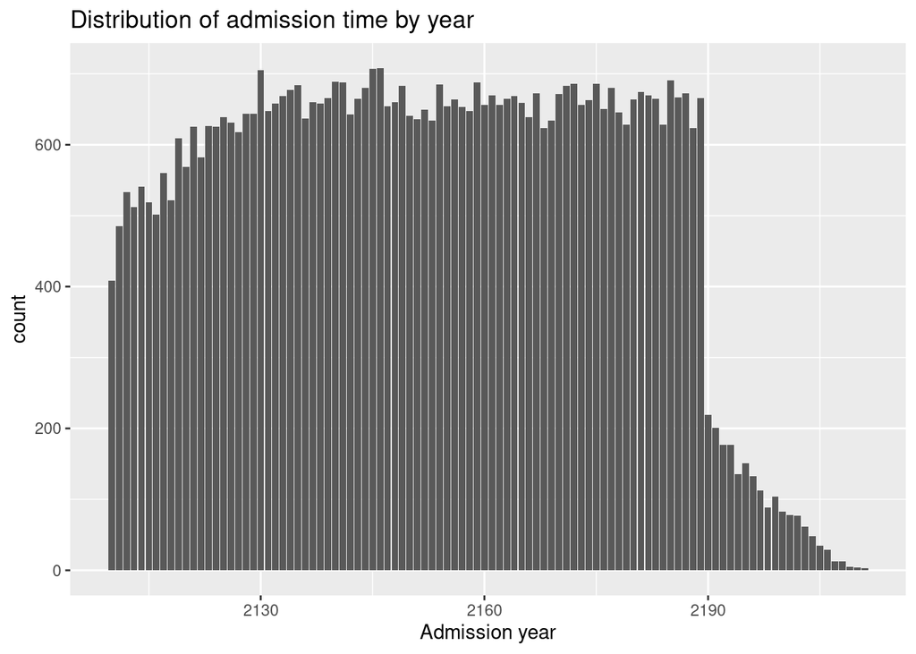

```r
ggplot(data = admissions_tble) +
  geom_bar(mapping = aes(x = year(admittime))) +
  labs(title = "Distribution of admission time by year") +
  labs(x = "Admission year")
```

- admission month

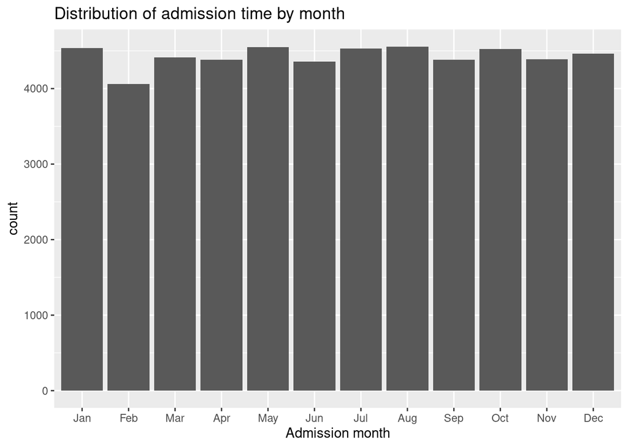

```r
ggplot(data = admissions_tble) +
  stat_count(mapping = aes(x = lubridate::month(admittime, label = T))) +
  labs(title = "Distribution of admission time by month") +
  labs(x = "Admission month")
```

- admission month day

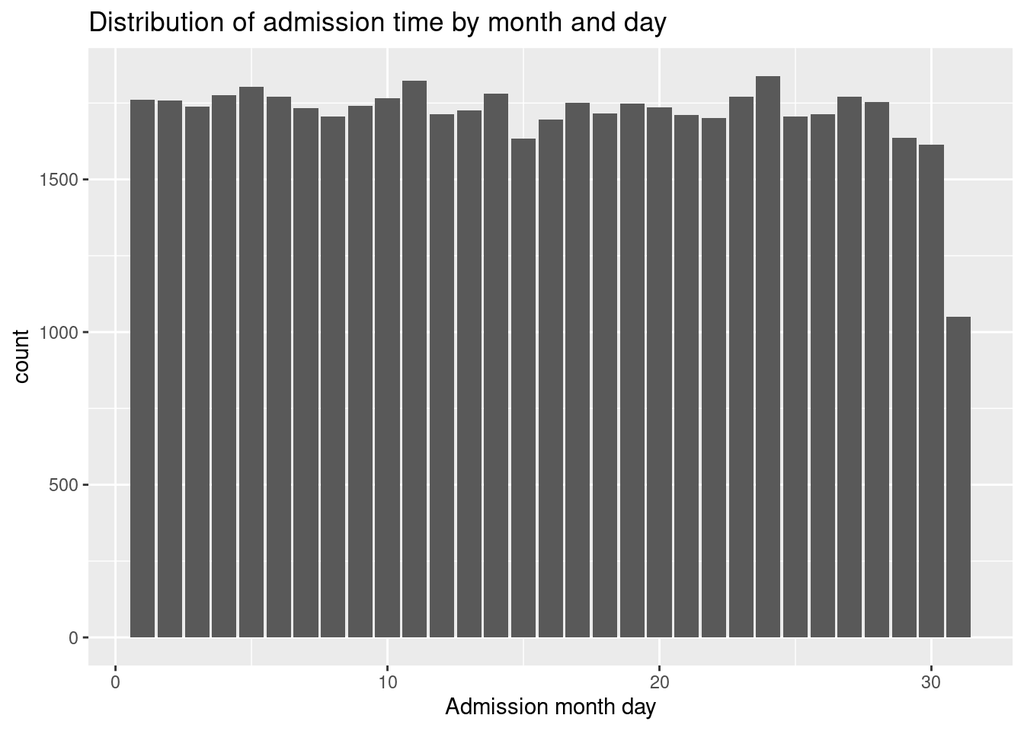

```r
ggplot(data = admissions_tble) +
  stat_count(mapping = aes(x = mday(admittime))) +
  labs(title = "Distribution of admission time by month and day") +
  labs(x = "Admission month day")
```

- admission week day

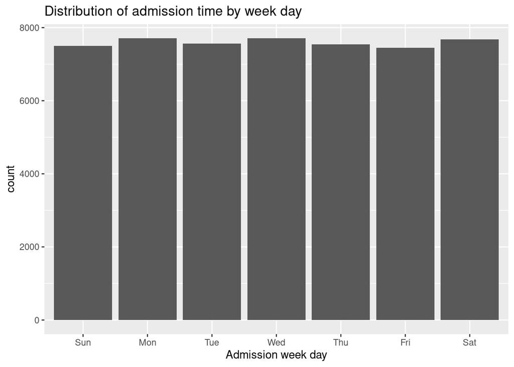

```r
ggplot(data = admissions_tble) +
  stat_count(mapping = aes(x = lubridate::wday(admittime, label = T))) +
  labs(title = "Distribution of admission time by week day") +
  labs(x = "Admission week day")
```

- admission hour (anything unusual?)

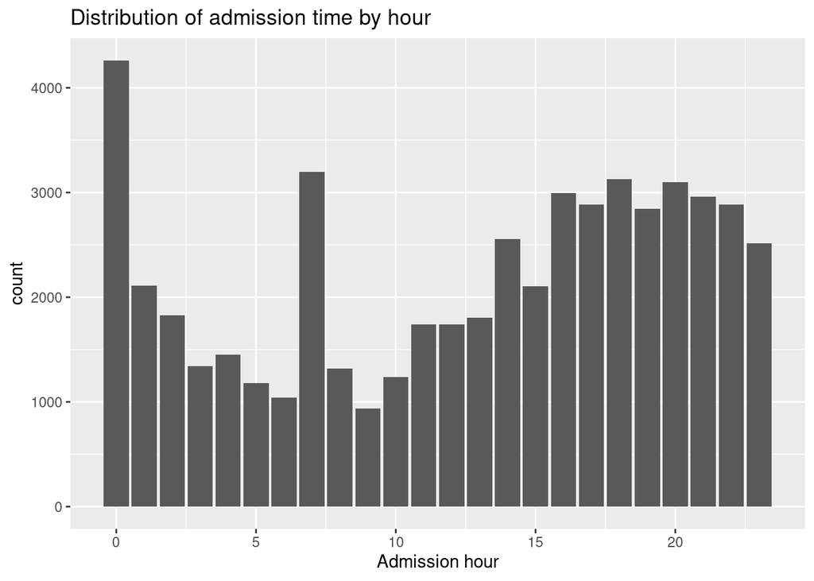

```r
ggplot(data = admissions_tble) +
  stat_count(mapping = aes(x = hour(admittime))) +
  labs(title = "Distribution of admission time by hour") +
  labs(x = "Admission hour")
```

**Solution:** From the above graph, 0 AM and 7 AM appear to be unusual since the frequencies are higher than other times despite a late night and an early morning. That may be caused by some operation of the hospital.

## Q4. `patients` data

Patient information is available in `patients.csv.gz`. See https://mimic.mit.edu/docs/iv/modules/core/patients/ for details of each field in this file. The first 10 lines are

```r
system(
  str_c(
    "zcat < ",
    shQuote(str_c(mimic_path, "/core/patients.csv.gz")),
    " | head"
  ),
  intern = TRUE
)
```

```
##  [1] "subject_id,gender,anchor_age,anchor_year,anchor_year_group,dod"
##  [2] "10000048,F,23,2126,2008 - 2010,"
##  [3] "10002723,F,0,2128,2017 - 2019,"
##  [4] "10003939,M,0,2184,2008 - 2010,"
##  [5] "10004222,M,0,2161,2014 - 2016,"
##  [6] "10005325,F,0,2154,2011 - 2013,"
##  [7] "10007338,F,0,2153,2017 - 2019,"
##  [8] "10008101,M,0,2142,2008 - 2010,"
##  [9] "10009872,F,0,2168,2014 - 2016,"
## [10] "10011333,F,0,2132,2014 - 2016,"
```

1. Import `patients.csv.gz` (https://mimic.mit.edu/docs/iv/modules/core/patients/) as a tibble `patients_tble` and only keep the patients who have a match in `icustays_tble` (according to `subject_id`).

**Solution:** I used `read_csv` to import this file as a tibble. The subset contains 53,150 rows.

```r
patients_master <- read_csv(str_c(mimic_path,"/core/patients.csv.gz"),
                            show_col_types = FALSE)
patients_tble <- patients_master %>%
  arrange(subject_id) %>%
  semi_join(icustays_tble, by = c("subject_id")) %>%
  print(width = Inf)
```

```
## # A tibble: 53,150 × 6
##    subject_id gender anchor_age anchor_year anchor_year_group dod
##         <dbl> <chr>       <dbl>       <dbl> <chr>             <date>
##  1   10000032 F              52        2180 2014 - 2016       NA
##  2   10000980 F              73        2186 2008 - 2010       NA
##  3   10001217 F              55        2157 2011 - 2013       NA
##  4   10001725 F              46        2110 2011 - 2013       NA
##  5   10001884 F              68        2122 2008 - 2010       2131-01-20
##  6   10002013 F              53        2156 2008 - 2010       NA
##  7   10002155 F              80        2128 2008 - 2010       2131-03-10
##  8   10002223 M              21        2158 2008 - 2010       NA
##  9   10002348 F              77        2112 2017 - 2019       NA
## 10   10002428 F              80        2155 2011 - 2013       NA
## # … with 53,140 more rows
```

2. Summarize variables `gender` and `anchor_age`, and explain any patterns you see.

**Solution:** I used a box plot and a bar plot to visualize the distribution of the two variables.

For the box plot:

- Both distributions are negatively skewed and have almost the same range;
- The 25th, 50th (median), and 75th percentile ages of women are higher than those of men.

For the bar plot:

- Many ages have more males than females;
- There is a significant number of patients with the maximum age (91 years).

```r
p1 <- ggplot(data = patients_tble, mapping = aes(x = gender, y = anchor_age)) +
  stat_boxplot(geom = "errorbar", width = 0.2) +
  geom_boxplot() +
  labs(title = "Distributions for anchor age by gender") +
  labs(x = "Gender", y = "Anchor age (years)")
p2 <- ggplot(data = patients_tble) +
  geom_bar(mapping = aes(x = anchor_age, fill = gender)) +
  labs(title = "") +
  labs(x = "Anchor age (years)", fill = "Gender")
max(patients_tble$anchor_age)
```

```
## [1] 91
```

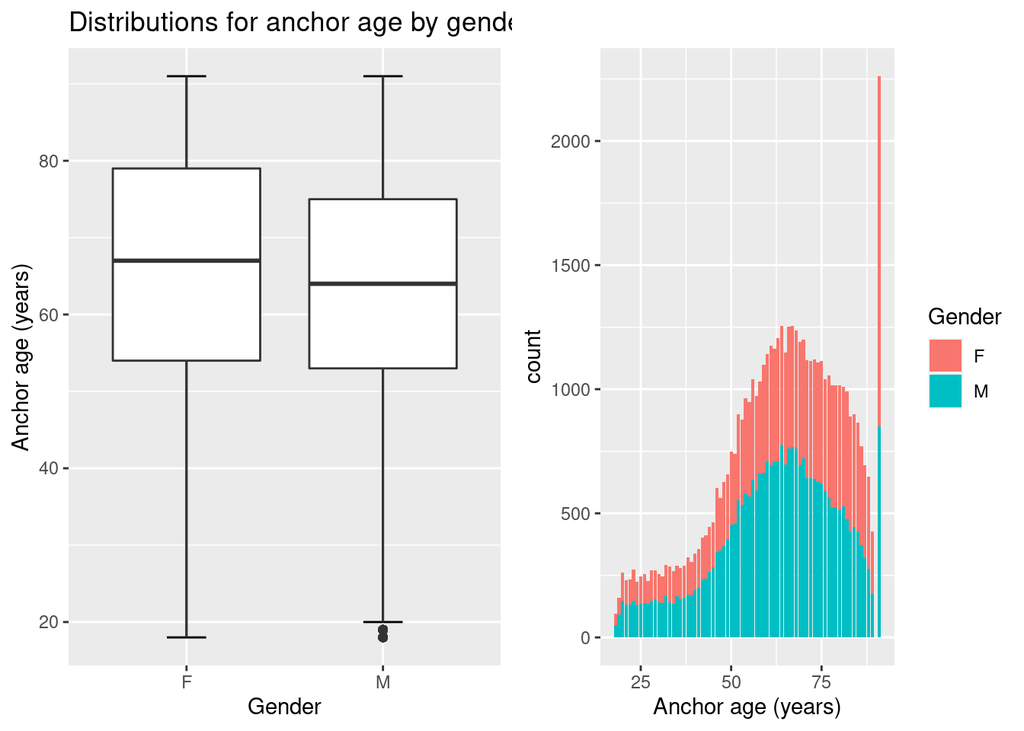

```r
gridExtra::grid.arrange(p1, p2, nrow = 1)
```

## Q5. Lab results

`labevents.csv.gz` (https://mimic.mit.edu/docs/iv/modules/hosp/labevents/) contains all laboratory measurements for patients. The first 10 lines are

```r
system(
  str_c(
    "zcat < ",
    shQuote(str_c(mimic_path, "/hosp/labevents.csv.gz")),
    " | head"
  ),
  intern = TRUE
)
```

```
##  [1] "labevent_id,subject_id,hadm_id,specimen_id,itemid,charttime,storetime,value,valuenum,valueuom,ref_range_lower,ref_range_upper,flag,priority,comments"
##  [2] "670,10000048,,6448755,51484,2126-11-22 19:20:00,2126-11-22 20:07:00,150,150,mg/dL,,,,STAT,"
##  [3] "673,10000048,,6448755,51491,2126-11-22 19:20:00,2126-11-22 20:07:00,6.5,6.5,units,5,8,,STAT,"
##  [4] "675,10000048,,6448755,51498,2126-11-22 19:20:00,2126-11-22 20:07:00,1.029,1.029, ,1.001,1.035,,STAT,"
##  [5] "683,10000048,,82729055,50861,2126-11-22 20:45:00,2126-11-23 00:55:00,39,39,IU/L,0,40,,STAT,"
##  [6] "684,10000048,,82729055,50862,2126-11-22 20:45:00,2126-11-23 00:55:00,4.7,4.7,g/dL,3.4,4.8,,STAT,"
##  [7] "685,10000048,,82729055,50863,2126-11-22 20:45:00,2126-11-23 00:55:00,45,45,IU/L,39,117,,STAT,"
##  [8] "686,10000048,,82729055,50868,2126-11-22 20:45:00,2126-11-22 21:32:00,13,13,mEq/L,8,20,,STAT,"
##  [9] "687,10000048,,82729055,50878,2126-11-22 20:45:00,2126-11-23 00:55:00,28,28,IU/L,0,40,,STAT,"
## [10] "688,10000048,,82729055,50882,2126-11-22 20:45:00,2126-11-22 21:32:00,26,26,mEq/L,22,32,,STAT,"
```

```r
system(
  str_c(
    "zcat < ",
    shQuote(str_c(mimic_path, "/hosp/d_labitems.csv.gz")),
    " | head"
  ),
  intern = TRUE
)
```

```
##  [1] "itemid,label,fluid,category,loinc_code"
##  [2] "51905, ,Other Body Fluid,Chemistry,"
##  [3] "51532,11-Deoxycorticosterone,Blood,Chemistry,"
##  [4] "51957,17-Hydroxycorticosteroids,Urine,Chemistry,"
##  [5] "51958,\"17-Ketosteroids, Urine\",Urine,Chemistry,"
##  [6] "52068,24 Hr,Blood,Hematology,"
##  [7] "51066,24 hr Calcium,Urine,Chemistry,"
##  [8] "51067,24 hr Creatinine,Urine,Chemistry,"
##  [9] "51068,24 hr Protein,Urine,Chemistry,"
## [10] "50853,25-OH Vitamin D,Blood,Chemistry,"
```

1. Find how many rows are in `labevents.csv.gz`.

**Solution:** There are 122,103,667 rows in `labevents.csv.gz`.

```r
system(
  str_c(
    "zcat < ",
    shQuote(str_c(mimic_path, "/hosp/labevents.csv.gz")),
    " | tail -n +2 | wc -l"
  ),
  intern = TRUE
)
```

```
## [1] "122103667"
```

2. We are interested in the lab measurements of creatinine (50912), potassium (50971), sodium (50983), chloride (50902), bicarbonate (50882), hematocrit (51221), white blood cell count (51301), glucose (50931), magnesium (50960), and calcium (50893). Retrieve a subset of `labevents.csv.gz` only containing these items for the patients in `icustays_tble` as a tibble `labevents_tble`.

Hint: `labevents.csv.gz` is a data file too big to be read in by the `read_csv` function in its default setting. Utilize the `col_select` and `lazy` options in the `read_csv` function to reduce the memory burden.

**Solution:** I imported this and used `left_join` to add `label` in `d_labitems.csv.gz` as a new variable. The subset has 16,698,462 rows.

```r
labevents_master <-
  read_csv(str_c(mimic_path,"/hosp/labevents_filtered_itemid.csv.gz"),
           col_types = cols_only(subject_id = col_double(),
                                 itemid = col_double(),
                                 charttime = col_datetime(),
                                 valuenum = col_double()),
           lazy = TRUE)
d_labitems_tble <- read_csv(str_c(mimic_path,"/hosp/d_labitems.csv.gz"))
# item list we plan to use (but we do not need this anymore)
choice_lab <- c("50912", "50971", "50983", "50902", "50882",
                "51221", "51301", "50931", "50960", "50893")
labevents_tble <- labevents_master
labevents_tble <- labevents_tble %>%
  arrange(subject_id, itemid) %>%
  # only contain these items for the patients in icustays_tble
  semi_join(icustays_tble, by = c("subject_id")) %>%
  # add label in d_labitems
  left_join(select(d_labitems_tble, itemid, label), by = c("itemid")) %>%
  print(width = Inf)
```

```
## # A tibble: 16,698,462 × 5
##    subject_id itemid charttime           valuenum label
##         <dbl>  <dbl> <dttm>                 <dbl> <chr>
##  1   10000032  50882 2180-03-23 11:51:00       27 Bicarbonate
##  2   10000032  50882 2180-05-06 22:25:00       27 Bicarbonate
##  3   10000032  50882 2180-05-07 05:05:00       28 Bicarbonate
##  4   10000032  50882 2180-06-03 12:00:00       28 Bicarbonate
##  5   10000032  50882 2180-06-03 12:00:00       29 Bicarbonate
##  6   10000032  50882 2180-06-22 11:15:00       26 Bicarbonate
##  7   10000032  50882 2180-06-26 16:10:00       26 Bicarbonate
##  8   10000032  50882 2180-06-27 05:10:00       25 Bicarbonate
##  9   10000032  50882 2180-07-23 06:39:00       25 Bicarbonate
## 10   10000032  50882 2180-07-23 21:45:00       21 Bicarbonate
## # … with 16,698,452 more rows
```

3. Further restrict `labevents_tble` to the first lab measurement during the ICU stay.

**Solution:** The following code made `labevents_tble` 51,623 rows. I used `select` to keep `subject_id` and ten lab measurements, or only 11 columns.

```r
if (file.exists("labevents_tble.rds")) {
  labevents_tble <- read_rds("labevents_tble.rds")
} else {
  labevents_tble <- labevents_tble %>%
    # add intime and outtime from icustays_tble to find the first lab measurement
    left_join(select(icustays_tble, subject_id, intime, outtime),
              by = c("subject_id")) %>%
    # keep only lab measurements between intime and outtime
    filter(charttime >= intime, charttime <= outtime) %>%
    # sort charttime in ascending order by subject_id and item_id
    group_by(subject_id, itemid) %>%
    arrange(charttime, .by_group = TRUE) %>%
    # keep only the first lab measurement by group
    slice_head(n = 1) %>%
    # keep only 11 columns and spread label and valuenum
    ungroup() %>%
    select(-c(itemid, charttime, intime, outtime)) %>%
    pivot_wider(names_from = label, values_from = valuenum) %>%
    # avoid space in column name
    rename(Calcium = "Calcium, Total", WBC = "White Blood Cells") %>%
    print(width = Inf) %>%
    write_rds("labevents_tble.rds")
}
```

```
## # A tibble: 51,623 × 11
##    subject_id Bicarbonate Calcium Chloride Creatinine Glucose Magnesium
##         <dbl>       <dbl>   <dbl>    <dbl>      <dbl>   <dbl>     <dbl>
##  1   10000032          21     9.3      102        0.5     115       2.3
##  2   10001217          23     8.2      104        0.4     113       1.9
##  3   10001725          24     9.1      106        0.8     146       1.5
##  4   10001884          33     9.8       96        1.1     148       2.2
##  5   10002013          23    NA        109        1.1      98       2.1
##  6   10002155          25     8.8      106        0.9      95       2
##  7   10002223          26     8.7      102        0.8      88       2
##  8   10002348          23     9.4      107        0.8     127       1.6
##  9   10002428          20     7.4       98        0.8      99       1.4
## 10   10002430          22     9.2      105        2.2     128       2.3
##    Potassium Sodium Hematocrit   WBC
##        <dbl>  <dbl>      <dbl> <dbl>
##  1       4.7    132       NA    NA
##  2       3.6    138       33.6  19
##  3       3.9    140       39.1  17
##  4       4      136       36    18.4
##  5       4      140       28.6  18.2
##  6       4.5    139       37.9   5.5
##  7       3.9    138       32.5  10.1
##  8       4.8    142       39.3   4.3
##  9       3.9    129       28.7  22.4
## 10       3.8    144       36.6  10.3
## # … with 51,613 more rows
```

4. Summarize the lab measurements by appropriate numerics and graphics.

**Solution:** For numeric, I used `summary` to output summary statistics, implying that some appear to have missing ant extreme values. Taking this into account, for graphics, I removed values below the 2.5th and above the 97.5th percentile and then displayed these distributions in the following box plots. The distributions for Creatinine, Glucose, and White Blood Cells (WBC) are far from normal distribution, unlike the others.

```r
# numerical summary
summary(labevents_tble[-1])
```

```
##   Bicarbonate       Calcium          Chloride       Creatinine
##  Min.   : 2.00   Min.   : 0.000   Min.   : 58.0   Min.   : 0.000
##  1st Qu.:21.00   1st Qu.: 7.900   1st Qu.:101.0   1st Qu.: 0.700
##  Median :23.00   Median : 8.400   Median :105.0   Median : 0.900
##  Mean   :22.96   Mean   : 8.349   Mean   :104.5   Mean   : 1.311
##  3rd Qu.:25.00   3rd Qu.: 8.800   3rd Qu.:108.0   3rd Qu.: 1.300
##  Max.   :49.00   Max.   :43.000   Max.   :153.0   Max.   :36.900
##  NA's   :278     NA's   :2810     NA's   :238     NA's   :257
##     Glucose         Magnesium        Potassium          Sodium
##  Min.   :   7.0   Min.   : 0.000   Min.   : 0.800   Min.   : 92.0
##  1st Qu.: 103.0   1st Qu.: 1.700   1st Qu.: 3.700   1st Qu.:136.0
##  Median : 124.0   Median : 2.000   Median : 4.100   Median :139.0
##  Mean   : 141.4   Mean   : 2.001   Mean   : 4.178   Mean   :138.5
##  3rd Qu.: 156.0   3rd Qu.: 2.200   3rd Qu.: 4.500   3rd Qu.:141.0
##  Max.   :2440.0   Max.   :47.000   Max.   :13.000   Max.   :180.0
##  NA's   :354      NA's   :1340     NA's   :264      NA's   :232
##    Hematocrit         WBC
##  Min.   : 4.30   Min.   :  0.00
##  1st Qu.:28.10   1st Qu.:  7.60
##  Median :32.60   Median : 10.60
##  Mean   :32.74   Mean   : 12.07
##  3rd Qu.:37.30   3rd Qu.: 14.50
##  Max.   :68.60   Max.   :572.50
##  NA's   :504     NA's   :627
```

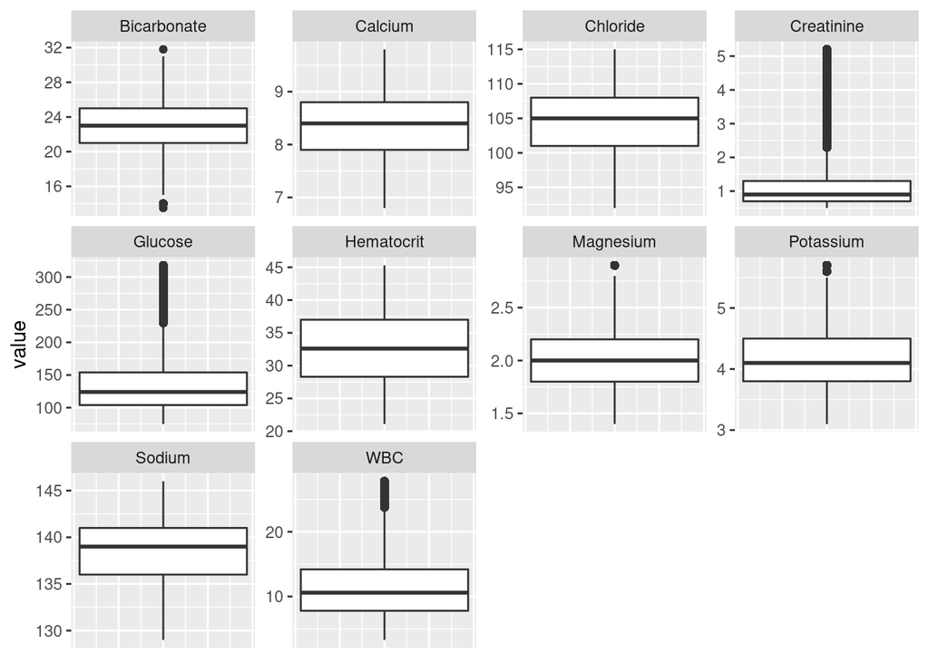

```r
# graphical summary
labevents_tble %>%
  select(2:11) %>%
  gather() %>%
  group_by(key) %>%
  filter(value > quantile(value, 0.025, na.rm = TRUE)
         & value < quantile(value, 0.975, na.rm = TRUE)) %>%
  ungroup %>%
  ggplot() +
  geom_boxplot(mapping = aes(y = value)) +
  facet_wrap(~key, scales = "free_y") +
  theme(axis.title.x = element_blank(),
        axis.text.x = element_blank(),
        axis.ticks.x = element_blank())
```

## Q6. Vitals from charted events

`chartevents.csv.gz` (https://mimic.mit.edu/docs/iv/modules/icu/chartevents/) contains all the charted data available for a patient. During their ICU stay, the primary repository of a patient’s information is their electronic chart. The `itemid` variable indicates a single measurement type in the database. The `value` variable is the value measured for `itemid`. The first 10 lines of `chartevents.csv.gz` are

```r
system(
  str_c(
    "zcat < ",
    shQuote(str_c(mimic_path, "/icu/chartevents.csv.gz")),
    " | head"),
  intern = TRUE
)
```

```
##  [1] "subject_id,hadm_id,stay_id,charttime,storetime,itemid,value,valuenum,valueuom,warning"
##  [2] "10003700,28623837,30600691,2165-04-24 05:10:00,2165-04-24 05:11:00,228236,0,0,,0"
##  [3] "10003700,28623837,30600691,2165-04-24 05:12:00,2165-04-24 05:14:00,225067,0,0,,0"
##  [4] "10003700,28623837,30600691,2165-04-24 05:12:00,2165-04-24 05:14:00,225070,1,1,,0"
##  [5] "10003700,28623837,30600691,2165-04-24 05:12:00,2165-04-24 05:14:00,225076,1,1,,0"
##  [6] "10003700,28623837,30600691,2165-04-24 05:12:00,2165-04-24 05:14:00,225078,1,1,,0"
##  [7] "10003700,28623837,30600691,2165-04-24 05:12:00,2165-04-24 05:14:00,225086,1,1,,0"
##  [8] "10003700,28623837,30600691,2165-04-24 05:12:00,2165-04-24 05:14:00,225091,1,1,,0"
##  [9] "10003700,28623837,30600691,2165-04-24 05:12:00,2165-04-24 05:14:00,225103,1,1,,0"
## [10] "10003700,28623837,30600691,2165-04-24 05:12:00,2165-04-24 05:14:00,225106,1,1,,0"
```

`d_items.csv.gz` (https://mimic.mit.edu/docs/iv/modules/icu/d_items/) is the dictionary for the `itemid` in `chartevents.csv.gz`.

```r
system(
  str_c(
    "zcat < ",
    shQuote(str_c(mimic_path, "/icu/d_items.csv.gz")),
    " | head"),
  intern = TRUE
)
```

```
##  [1] "itemid,label,abbreviation,linksto,category,unitname,param_type,lownormalvalue,highnormalvalue"
##  [2] "220003,ICU Admission date,ICU Admission date,datetimeevents,ADT,,Date and time,,"
##  [3] "220045,Heart Rate,HR,chartevents,Routine Vital Signs,bpm,Numeric,,"
##  [4] "220046,Heart rate Alarm - High,HR Alarm - High,chartevents,Alarms,bpm,Numeric,,"
##  [5] "220047,Heart Rate Alarm - Low,HR Alarm - Low,chartevents,Alarms,bpm,Numeric,,"
##  [6] "220048,Heart Rhythm,Heart Rhythm,chartevents,Routine Vital Signs,,Text,,"
##  [7] "220050,Arterial Blood Pressure systolic,ABPs,chartevents,Routine Vital Signs,mmHg,Numeric,90,140"
##  [8] "220051,Arterial Blood Pressure diastolic,ABPd,chartevents,Routine Vital Signs,mmHg,Numeric,60,90"
##  [9] "220052,Arterial Blood Pressure mean,ABPm,chartevents,Routine Vital Signs,mmHg,Numeric,,"
## [10] "220056,Arterial Blood Pressure Alarm - Low,ABP Alarm - Low,chartevents,Alarms,mmHg,Numeric,,"
```

1. We are interested in the vitals for ICU patients: heart rate (220045), mean non-invasive blood pressure (220181), systolic non-invasive blood pressure (220179), body temperature in Fahrenheit (223761), and respiratory rate (220210). Retrieve a subset of `chartevents.csv.gz` only containing these items for the patients in `icustays_tble` as a tibble `chartevents_tble`.

**Solution:** Importing this and adding `label` in `d_items.csv.gz` as a new column created a tibble with 23,679,058 × 6. The subset retained all the rows of the original.

```r
chartevents_master <-
  read_csv(str_c(mimic_path,"/icu/chartevents_filtered_itemid.csv.gz"),
           col_types = cols_only(subject_id = col_double(),
                                 hadm_id = col_double(),
                                 itemid = col_double(),
                                 itemid = col_double(),
                                 charttime = col_datetime(),
                                 valuenum = col_double()),
           lazy = TRUE)
d_items_tble <- read_csv(str_c(mimic_path,"/icu/d_items.csv.gz"))
# item list we plan to use (but we do not need this anymore)
choice2 <- c("220045", "220181", "220179", "223761", "220210")
chartevents_tble <- chartevents_master
chartevents_tble <- chartevents_tble %>%
  # only containing these items for the patients in icustays_tble
  semi_join(icustays_tble, by = c("subject_id")) %>%
  # add label in d_items
  left_join(select(d_items_tble, itemid, label), by = c("itemid")) %>%
  print(width = Inf)
```

```
## # A tibble: 23,679,058 × 6
##    subject_id  hadm_id charttime           itemid valuenum
##         <dbl>    <dbl> <dttm>               <dbl>    <dbl>
##  1   10003700 28623837 2165-04-24 05:28:00 220179    152
##  2   10003700 28623837 2165-04-24 05:28:00 220181    110
##  3   10003700 28623837 2165-04-24 05:30:00 220045     65
##  4   10003700 28623837 2165-04-24 05:30:00 220210     14
##  5   10003700 28623837 2165-04-24 05:38:00 223761     97.6
##  6   10003700 28623837 2165-04-24 06:00:00 220045     56
##  7   10003700 28623837 2165-04-24 06:00:00 220179    126
##  8   10003700 28623837 2165-04-24 06:00:00 220181     88
##  9   10003700 28623837 2165-04-24 06:00:00 220210     14
## 10   10003700 28623837 2165-04-24 06:09:00 220045     55
##    label
##    <chr>
##  1 Non Invasive Blood Pressure systolic
##  2 Non Invasive Blood Pressure mean
##  3 Heart Rate
##  4 Respiratory Rate
##  5 Temperature Fahrenheit
##  6 Heart Rate
##  7 Non Invasive Blood Pressure systolic
##  8 Non Invasive Blood Pressure mean
##  9 Respiratory Rate
## 10 Heart Rate
## # … with 23,679,048 more rows
```

2. Further restrict `chartevents_tble` to the first vital measurement during the ICU stay.

**Solution:** I ran almost the same code as Q5-3 and obtained a tibble with 53,136 × 6, which consists of only `subject_id` and five vital measurements.

```r
# file.remove("chartevents_tble.rds")
if (file.exists("chartevents_tble.rds")) {
  chartevents_tble <- read_rds("chartevents_tble.rds")
} else {
  chartevents_tble <- chartevents_tble %>%
    # add intime and outtime from icustays_tble to find the first vital measurement
    left_join(select(icustays_tble, subject_id, intime, outtime),
              by = c("subject_id")) %>%
    # keep only vital measurements between intime and outtime
    filter(charttime >= intime, charttime <= outtime) %>%
    # sort charttime in ascending order by subject_id and item_id
    group_by(subject_id, itemid) %>%
    arrange(charttime, .by_group = TRUE) %>%
    # keep only the first vital measurement by group
    slice_head(n = 1) %>%
    # restrict columns and spread label and valuenum
    ungroup() %>%
    select(c(subject_id, label, valuenum)) %>%
    pivot_wider(names_from = label, values_from = valuenum) %>%
    # avoid space in column name
    rename(HR = "Heart Rate", RR = "Respiratory Rate",
           Mean_BP = "Non Invasive Blood Pressure systolic",
           Systolic_BP = "Non Invasive Blood Pressure mean",
           BT = "Temperature Fahrenheit") %>%
    print(width = Inf) %>%
    write_rds("chartevents_tble.rds")
}
```

```
## # A tibble: 53,136 × 6
##    subject_id    HR Mean_BP Systolic_BP    RR    BT
##         <dbl> <dbl>   <dbl>       <dbl> <dbl> <dbl>
##  1   10000032    91      84          56    24  98.7
##  2   10000980    77     150          92    23  98
##  3   10001217    86     151         104    18  98.5
##  4   10001725    55      73          59    19  97.7
##  5   10001884    38     180          46    10  98.1
##  6   10002013    80     104          77    14  97.2
##  7   10002155    68     126          78    18  95.9
##  8   10002223   100     123          80    29  98.6
##  9   10002348    72     129          85    14  97.9
## 10   10002428   124      87          53    25 103.
## # … with 53,126 more rows
```

3. Summarize these vital measurements by appropriate numerics and graphics.

**Solution:** As with Q5-4, I output summary statistics, which indicates some extreme values exist. Then I used box plots that omitted values outside from the 2.5th to 97.5th percentile to make the distributions more visible. All distributions seem to be approximately close to normal.

```r
# numerical summary
summary(chartevents_tble[-1])
```

```
##        HR            Mean_BP         Systolic_BP              RR
##  Min.   :  0.00   Min.   :    0.0   Min.   :     0.00   Min.   :  0.00
##  1st Qu.: 74.00   1st Qu.:  106.0   1st Qu.:    70.00   1st Qu.: 15.00
##  Median : 85.00   Median :  122.0   Median :    81.00   Median : 18.00
##  Mean   : 87.47   Mean   :  123.8   Mean   :    87.42   Mean   : 18.69
##  3rd Qu.: 99.00   3rd Qu.:  139.0   3rd Qu.:    93.00   3rd Qu.: 22.00
##  Max.   :941.00   Max.   :12262.0   Max.   :140119.00   Max.   :180.00
##  NA's   :1        NA's   :669       NA's   :690         NA's   :48
##        BT
##  Min.   :  0.00
##  1st Qu.: 97.60
##  Median : 98.10
##  Mean   : 98.03
##  3rd Qu.: 98.70
##  Max.   :106.00
##  NA's   :940
```

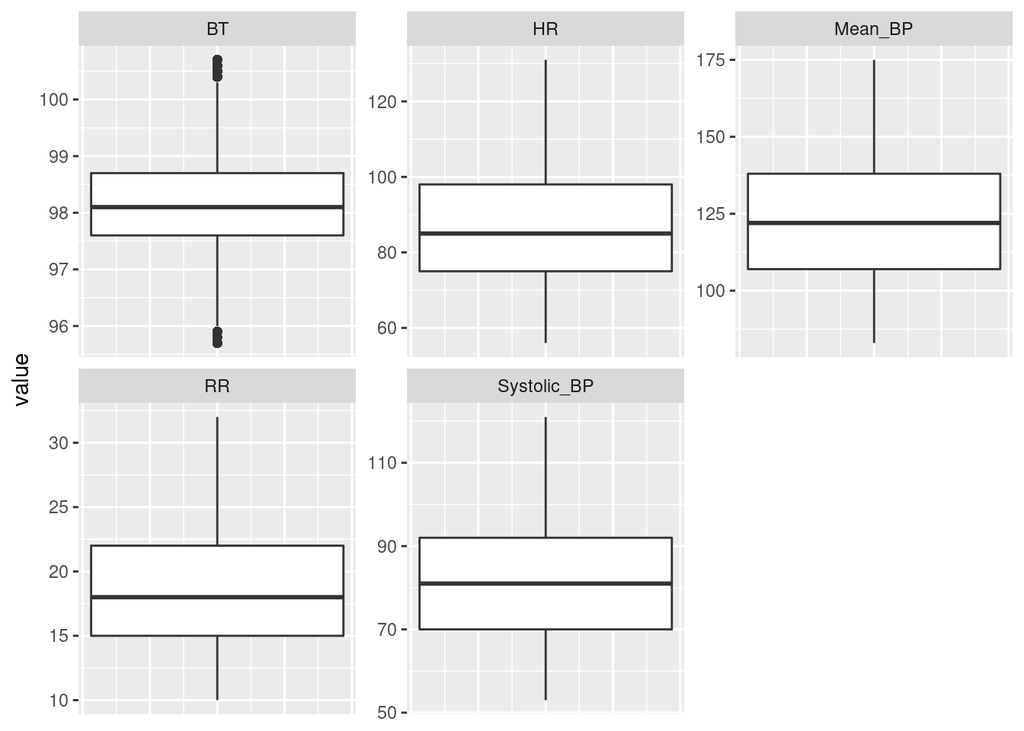

```r
# graphical summary
chartevents_tble %>%
  select(2:6) %>%
  gather() %>%
  group_by(key) %>%
  filter(value > quantile(value, 0.025, na.rm = TRUE)
         & value < quantile(value, 0.975, na.rm = TRUE)) %>%
  ungroup %>%
  ggplot() +
  geom_boxplot(mapping = aes(y = value)) +
  facet_wrap(~key, scales = "free_y") +
  theme(axis.title.x = element_blank(),
        axis.text.x = element_blank(),
        axis.ticks.x = element_blank())
```

## Q7. Putting things together

Let us create a tibble `mimic_icu_cohort` for all ICU stays, where rows are

- first ICU stay of each unique adult (age at admission > 18)

and columns contain at least following variables

- all variables in `icustays.csv.gz`
- all variables in `admission.csv.gz`
- all variables in `patients.csv.gz`
- first lab measurements during ICU stay
- first vital measurements during ICU stay
- an indicator variable `thirty_day_mort` whether the patient died within 30 days of hospital admission (30 day mortality)

**Solution:** Here is the code to create `mimic_icu_cohort` with 53,065 rows and 43 columns. I set `thirty_day_mort` as `TRUE` if a person died within 30 days; `FALSE` otherwise. I thought first that patients who haven’t died were in another category, though.

```r
# file.remove("mimic_icu_cohort.rds")
if (file.exists("mimic_icu_cohort.rds")) {
  mimic_icu_cohort <- read_rds("mimic_icu_cohort.rds")
} else {
  mimic_icu_cohort <- icustays_tble %>%
    left_join(admissions_tble, by = c("subject_id", "hadm_id")) %>%
    left_join(patients_tble, by = c("subject_id")) %>%
    left_join(labevents_tble, by = c("subject_id")) %>%
    left_join(chartevents_tble, by = c("subject_id")) %>%
    # compute age at admission
    mutate(age_hadm = anchor_age + year(admittime) - anchor_year) %>%
    # keep only patients aged over 18 at admission
    filter(age_hadm > 18) %>%
    # create thirty_day_mort with T if a patient died <= 30 days and F if not
    mutate(thirty_day_mort =
             ifelse(is.na(deathtime), "FALSE",
                    ifelse(as.Date(deathtime) - as.Date(admittime) <= 30,
                           "TRUE", "FALSE"))) %>%
    print(width = Inf) %>%
    write_rds("mimic_icu_cohort.rds")
}
```

```
## # A tibble: 53,065 × 43
##    subject_id  hadm_id  stay_id first_careunit
##         <dbl>    <dbl>    <dbl> <chr>
##  1   10000032 29079034 39553978 Medical Intensive Care Unit (MICU)
##  2   10000980 26913865 39765666 Medical Intensive Care Unit (MICU)
##  3   10001217 24597018 37067082 Surgical Intensive Care Unit (SICU)
##  4   10001725 25563031 31205490 Medical/Surgical Intensive Care Unit (MICU/SICU)
##  5   10001884 26184834 37510196 Medical Intensive Care Unit (MICU)
##  6   10002013 23581541 39060235 Cardiac Vascular Intensive Care Unit (CVICU)
##  7   10002155 23822395 33685454 Coronary Care Unit (CCU)
##  8   10002223 22494570 39638202 Trauma SICU (TSICU)
##  9   10002348 22725460 32610785 Neuro Intermediate
## 10   10002428 28662225 33987268 Medical Intensive Care Unit (MICU)
##    last_careunit                                    intime
##    <chr>                                            <dttm>
```

[output cut: 107 more lines]

```r
table(mimic_icu_cohort$thirty_day_mort)
```

```
##
## FALSE  TRUE
## 47853  5212
```

## Q8. Exploratory data analysis (EDA)

Summarize following information using appropriate numerics or graphs.

- `thirty_day_mort` vs demographic variables (ethnicity, language, insurance, marital_status, gender, age at hospital admission)

**Solution:** I used bar plots for categorical variables (ethnicity, language, insurance, marital_status and gender) and a box plot for a numerical variable (age at hospital admission).

- `thirty_day_mort` vs ethnicity

**Brief comment:** The percentage of white patients who died within 30 days is lower than that of those who did not, while the proportion of the unknown has the opposite relationship.

```r
# numerical information
round(prop.table(table(mimic_icu_cohort$ethnicity,
                       mimic_icu_cohort$thirty_day_mort) ,2), 2)
```

```
##
##                                 FALSE TRUE
##   AMERICAN INDIAN/ALASKA NATIVE  0.00 0.00
##   ASIAN                          0.03 0.03
##   BLACK/AFRICAN AMERICAN         0.09 0.07
##   HISPANIC/LATINO                0.04 0.02
##   OTHER                          0.05 0.04
##   UNABLE TO OBTAIN               0.01 0.02
##   UNKNOWN                        0.10 0.22
##   WHITE                          0.68 0.59
```

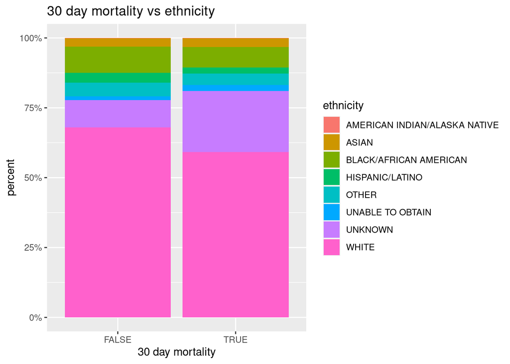

```r
# graphical information
mimic_icu_cohort %>%
  ggplot() +
  geom_bar(mapping = aes(x = thirty_day_mort, fill = ethnicity),
           position = "fill") +
  scale_y_continuous(labels = scales::percent) +
  labs(x = "30 day mortality", y = "percent") +
  scale_x_discrete(limits = ) +
  labs(title = "30 day mortality vs ethnicity")
```

- `thirty_day_mort` vs language, insurance, marital_status, and gender

**Brief comment:**

- For language, no different trends observe between the two categories: About 90% of the patients speak English.
- For insurance, patients who died within 30 days are more likely to have medicare than those who did not, rather than other insurances.
- For marital status (excluding `NA`), the adult patients who died within 30 days have a smaller proportion of the single than those who did not die, but a larger proportion of the widowed.
- For gender, there is little difference in the ratio of men to women between them.

```r
# numerical information
round(prop.table(table(mimic_icu_cohort$language,
                       mimic_icu_cohort$thirty_day_mort) ,2), 2)
```

```
##
##           FALSE TRUE
##   ?        0.10 0.11
##   ENGLISH  0.90 0.89
```

```r
round(prop.table(table(mimic_icu_cohort$insurance,
                       mimic_icu_cohort$thirty_day_mort) ,2), 2)
```

```
##
##            FALSE TRUE
##   Medicaid  0.07 0.06
##   Medicare  0.42 0.53
##   Other     0.51 0.41
```

```r
round(prop.table(table(mimic_icu_cohort$marital_status,
                       mimic_icu_cohort$thirty_day_mort) ,2), 2)
```

```
##
##            FALSE TRUE
##   DIVORCED  0.08 0.07
##   MARRIED   0.50 0.49
##   SINGLE    0.30 0.24
##   WIDOWED   0.13 0.20
```

```r
round(prop.table(table(mimic_icu_cohort$gender,
                       mimic_icu_cohort$thirty_day_mort) ,2), 2)
```

```
##
##     FALSE TRUE
##   F  0.44 0.46
##   M  0.56 0.54
```

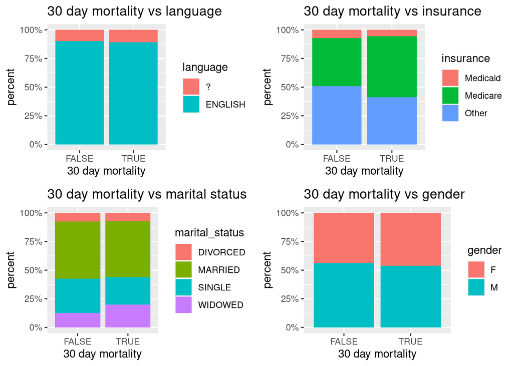

```r
# graphical information
q1 <- mimic_icu_cohort %>%
  ggplot() +
  geom_bar(mapping = aes(x = thirty_day_mort, fill = language),
           position = "fill") +
  scale_y_continuous(labels = scales::percent) +
  labs(x = "30 day mortality", y = "percent") +
  labs(title = "30 day mortality vs language")
q2 <- mimic_icu_cohort %>%
  ggplot() +
  geom_bar(mapping = aes(x = thirty_day_mort, fill = insurance),
           position = "fill") +
  scale_y_continuous(labels = scales::percent) +
  labs(x = "30 day mortality", y = "percent") +
  labs(title = "30 day mortality vs insurance")
q3 <- subset(mimic_icu_cohort, !is.na(marital_status)) %>%
  ggplot() +
  geom_bar(mapping = aes(x = thirty_day_mort, fill = marital_status),
           position = "fill") +
  scale_y_continuous(labels = scales::percent) +
  labs(x = "30 day mortality", y = "percent") +
  labs(title = "30 day mortality vs marital status")
q4 <- mimic_icu_cohort %>%
  ggplot() +
  geom_bar(mapping = aes(x = thirty_day_mort, fill = gender),
           position = "fill") +
  scale_y_continuous(labels = scales::percent) +
  labs(x = "30 day mortality", y = "percent") +
  labs(title = "30 day mortality vs gender")
gridExtra::grid.arrange(q1, q2, q3, q4, nrow = 2)
```

- `thirty_day_mort` vs age at hospital admission

**Brief comment:** Patients aged over 18 who died within 30 days tend to be older than those who did not.

```r
# numerical information
tapply(mimic_icu_cohort$age_hadm, mimic_icu_cohort$thirty_day_mort, summary)
```

```
## $`FALSE`
##    Min. 1st Qu.  Median    Mean 3rd Qu.    Max.
##   19.00   53.00   66.00   63.81   77.00  102.00
##
## $`TRUE`
##    Min. 1st Qu.  Median    Mean 3rd Qu.    Max.
##   19.00   61.00   74.00   71.28   84.00  100.00
```

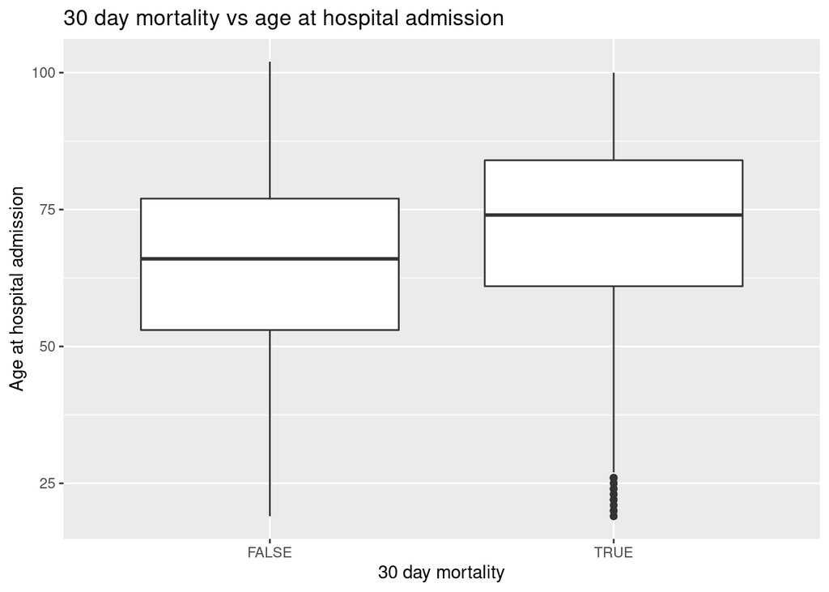

```r
# graphical information
ggplot(data = mimic_icu_cohort) +
  geom_boxplot(aes(x = thirty_day_mort, y = age_hadm)) +
  labs(title = "30 day mortality vs age at hospital admission") +
  labs(x = "30 day mortality") +
  labs(y = "Age at hospital admission")
```

- `thirty_day_mort` vs first lab measurements

**Solution:** I used a similar method with Q5-4 except for grouping by `thirty_day_mort` as follows.

```r
# numerical summary
mimic_icu_cohort %>%
  select(c(27:36, 43)) %>%
  gather(key = key, value = value, -thirty_day_mort) %>%
  filter(!is.na(value)) %>%
  filter(value > quantile(value, 0.025, na.rm = TRUE)
         & value < quantile(value, 0.975, na.rm = TRUE)) %>%
  group_by(key, thirty_day_mort) %>%
  summarize(Mean   =     mean(value,       na.rm = TRUE),
            Median =   median(value,       na.rm = TRUE),
            SD     =       sd(value,       na.rm = TRUE),
            Min    =      min(value,       na.rm = TRUE),
            Max    =      max(value,       na.rm = TRUE),
            Q1     = quantile(value, 0.25, na.rm = TRUE),
            Q3     = quantile(value, 0.75, na.rm = TRUE))
```

[output not shown]

```
## # A tibble: 20 × 9
## # Groups:   key [10]
##    key         thirty_day_mort   Mean Median     SD   Min   Max    Q1    Q3
##    <chr>       <chr>            <dbl>  <dbl>  <dbl> <dbl> <dbl> <dbl> <dbl>
##  1 Bicarbonate FALSE            23.2    23    4.19    3    49    21    25
##  2 Bicarbonate TRUE             20.8    21    5.84    2    48    17    24
##  3 Calcium     FALSE             8.36    8.4  0.810   1.8  27.5   7.9   8.8
##  4 Calcium     TRUE              8.22    8.2  1.22    1.6  43     7.6   8.8
##  5 Chloride    FALSE           105.    105    6.12   58   153   101   108
##  6 Chloride    TRUE            103.    104    7.84   61   140    99   108
##  7 Creatinine  FALSE             1.57    1.1  1.66    0.8  36.9   0.9   1.5
##  8 Creatinine  TRUE              2.04    1.5  1.58    0.8  23.1   1.1   2.4
##  9 Glucose     FALSE           114.    113   21.6     8   156    98   130
## 10 Glucose     TRUE            113.    115   26.8     7   156    95   134
## 11 Hematocrit  FALSE            32.8    32.7  6.43    6.4  68.6  28.1  37.3
## 12 Hematocrit  TRUE             32.5    32.1  7.22    4.3  62.1  27.4  37.2
## 13 Magnesium   FALSE             2.00    2    0.510   0.8  47     1.7   2.2
## 14 Magnesium   TRUE              2.03    2    0.465   0.8   8.7   1.7   2.2
## 15 Potassium   FALSE             4.16    4.1  0.676   0.8  13     3.7   4.5
## 16 Potassium   TRUE              4.33    4.2  0.904   1.4   9.6   3.7   4.8
## 17 Sodium      FALSE           138.    139    4.58   92   156   136   141
## 18 Sodium      TRUE            138.    139    6.19   97   156   135   142
## 19 WBC         FALSE            11.6    10.4  6.65    0.8 156.    7.6  14.2
## 20 WBC         TRUE             14.8    12.7 10.6     0.8 156.    8.7  18.1
```

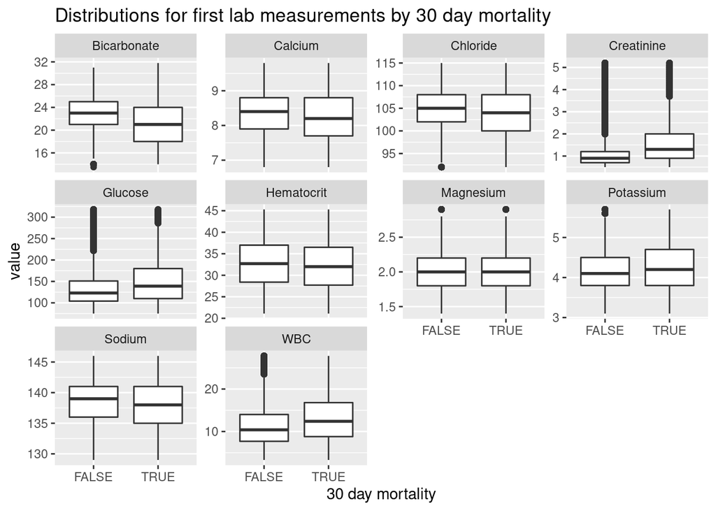

```r
# graphical summary
mimic_icu_cohort %>%
  gather(27:36, key = "key", value = "value") %>%
  group_by(key) %>%
  filter(value > quantile(value, 0.025, na.rm = TRUE)
         & value < quantile(value, 0.975, na.rm = TRUE)) %>%
  ungroup %>%
  ggplot(mapping = aes(x = thirty_day_mort, y = value)) +
  geom_boxplot() +
  labs(x = "30 day mortality") +
  facet_wrap(~key, scales = "free_y") +
  labs(title = "Distributions for first lab measurements by 30 day mortality")
```

**Brief comment:** For Bicarbonate and Creatinine, there appear to be big differences between the two categories because one of the medians is closer to the edge of the other box. Also, it may be worth testing whether there are statistically significant differences for glucose and white blood cells as well.

- `thirty_day_mort` vs first vital measurements

**Solution:** I used a similar method with Q6-3 except for grouping by `thirty_day_mort`.

```r
# numerical summary
mimic_icu_cohort %>%
  select(c(37:41, 43)) %>%
  gather(key = key, value = value, -thirty_day_mort) %>%
  filter(!is.na(value)) %>%
  filter(value > quantile(value, 0.025, na.rm = TRUE)
         & value < quantile(value, 0.975, na.rm = TRUE)) %>%
  group_by(key, thirty_day_mort) %>%
  summarize(Mean   =     mean(value,       na.rm = TRUE),
            Median =   median(value,       na.rm = TRUE),
            SD     =       sd(value,       na.rm = TRUE),
            Min    =      min(value,       na.rm = TRUE),
            Max    =      max(value,       na.rm = TRUE),
            Q1     = quantile(value, 0.25, na.rm = TRUE),
            Q3     = quantile(value, 0.75, na.rm = TRUE))
```

[output not shown]

```
## # A tibble: 10 × 9
## # Groups:   key [5]
##    key         thirty_day_mort  Mean Median    SD   Min   Max    Q1    Q3
##    <chr>       <chr>           <dbl>  <dbl> <dbl> <dbl> <dbl> <dbl> <dbl>
##  1 BT          FALSE            98.1   98.2  2.23  33.8  106   97.6  98.7
##  2 BT          TRUE             97.5   98    5.59  30.9  106.  97.4  98.7
##  3 HR          FALSE            86.6   84   18.9   25    152   74    98
##  4 HR          TRUE             92.7   92   21.4   24    152   77   108
##  5 Mean_BP     FALSE           118.   119   18.4   36    152  105   132
##  6 Mean_BP     TRUE            113.   113   21.5   31    152   98   130
##  7 RR          FALSE            20.0   19    5.36  14    152   16    22
##  8 RR          TRUE             22.2   21    6.22  14    115   18    25
##  9 Systolic_BP FALSE            82.4   81   17.4   14    152   70    93
## 10 Systolic_BP TRUE             79.9   78   20.1   19    152   66    93
```

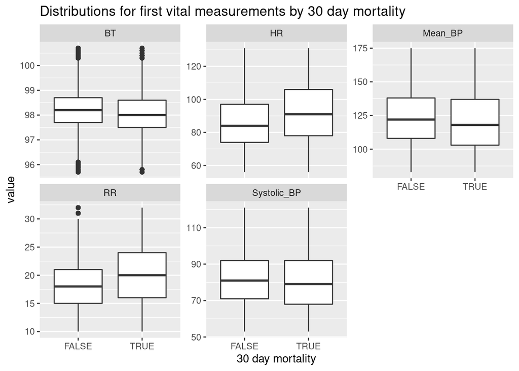

```r
# graphical summary
mimic_icu_cohort %>%
  gather(37:41, key = "key", value = "value") %>%
  group_by(key) %>%
  filter(value > quantile(value, 0.025, na.rm = TRUE)
         & value < quantile(value, 0.975, na.rm = TRUE)) %>%
  ungroup %>%
  ggplot(mapping = aes(x = thirty_day_mort, y = value)) +
  geom_boxplot() +
  labs(x = "30 day mortality") +
  facet_wrap(~key, scales = "free_y") +
  labs(title =
         "Distributions for first vital measurements by 30 day mortality")
```

**Brief comment:** The values for Heart Rate (HR) and Respiratory Rate (RR) tend to be relatively higher for patients who died within 30 days than those who did not. For the rest, no major differences can be seen.

- `thirty_day_mort` vs first ICU unit

**Solution:** I summarized this in a similar way to `thirty_day_mort` vs demographic variables.

```r
# numerical summary
round(prop.table(table(mimic_icu_cohort$first_careunit,
                       mimic_icu_cohort$thirty_day_mort) ,2), 2)
```

```
##
##                                                    FALSE TRUE
##   Cardiac Vascular Intensive Care Unit (CVICU)      0.19 0.05
##   Coronary Care Unit (CCU)                          0.11 0.14
##   Medical Intensive Care Unit (MICU)                0.18 0.27
##   Medical/Surgical Intensive Care Unit (MICU/SICU)  0.16 0.20
##   Neuro Intermediate                                0.03 0.01
##   Neuro Stepdown                                    0.01 0.00
##   Neuro Surgical Intensive Care Unit (Neuro SICU)   0.02 0.04
##   Surgical Intensive Care Unit (SICU)               0.15 0.17
##   Trauma SICU (TSICU)                               0.13 0.13
```

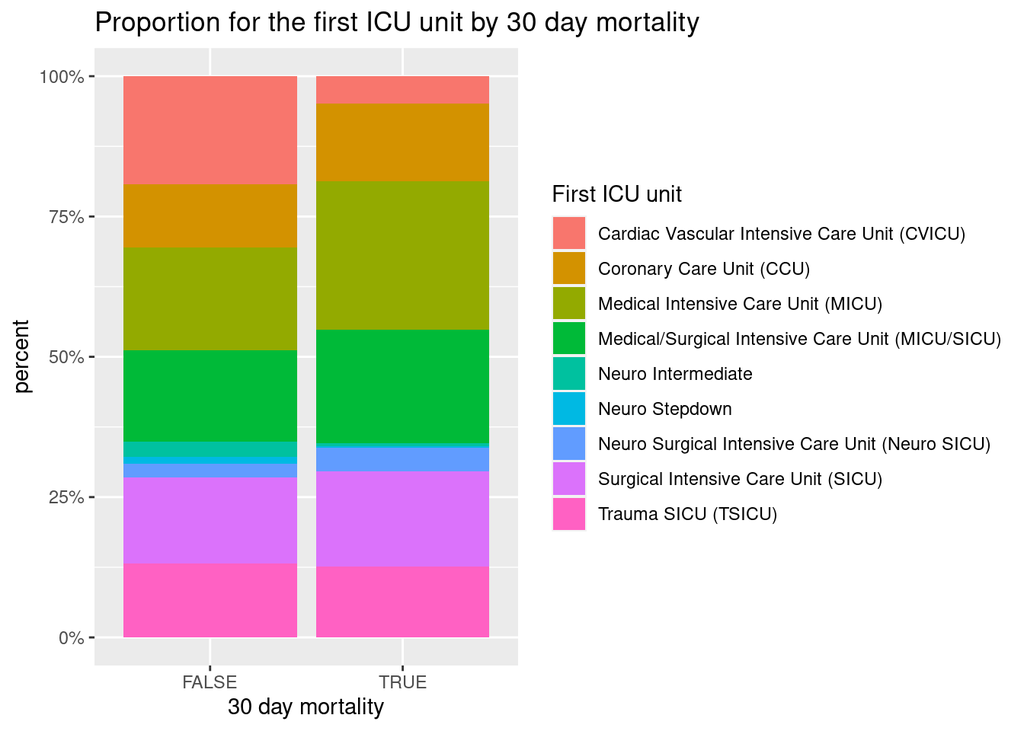

```r
# graphical summary
mimic_icu_cohort %>%
  ggplot() +
  geom_bar(mapping = aes(x = thirty_day_mort, fill = first_careunit),
           position = "fill") +
  labs(y = "percent") +
  scale_y_continuous(labels = scales::percent) +
  labs(title = "Proportion for the first ICU unit by 30 day mortality") +
  labs(x = "30 day mortality", fill = "First ICU unit")
```

**Brief comment:** The proportion of CVICU for patients who died within 30 days is 14 points lower than that of those who did not. On the other hand, for MICU, the proportion of patients who died within 30 days is 9 points higher. Other than that, there appears to be little difference.